# Direct Use Nonparametric

SHMTools Example - Non_Parametric_Detectors Level

← Back to Index [GitHub Repository](https://github.com/shmtools/shmtools-python) [Documentation](https://shmtools.readthedocs.io)

# Direct Use of Nonparametric Outlier Detection

## Introduction

This example demonstrates nonparametric outlier detection using kernel density estimation (KDE). The algorithm learns a nonparametric probability density function from undamaged baseline data and identifies outliers as points with low probability density.

Data from the **3-story structure** dataset are used to extract AR model features, which are then analyzed using kernel density estimation for damage detection.

**References:**

Figueiredo, E., Park, G., Figueiras, J., Farrar, C., & Worden, K. (2009). Structural Health Monitoring Algorithm Comparisons using Standard Data Sets. Los Alamos National Laboratory Report: LA-14393.

**SHMTools functions used:**

- `ar_model_shm`
- `learn_kernel_density_shm`
- `score_kernel_density_shm`
- `roc_shm`
- `epanechnikov_kernel_shm`

```python
import numpy as np
import matplotlib.pyplot as plt
from scipy import stats

# Import shmtools (installed package)
from examples.data import import_3story_structure_shm
from shmtools.features.time_series import ar_model_shm
from shmtools.classification.nonparametric import (
    learn_kernel_density_shm,
    score_kernel_density_shm,
    epanechnikov_kernel_shm
)
from shmtools.classification.outlier_detection import roc_shm

# Set up plotting
plt.style.use('default')
plt.rcParams['figure.figsize'] = (12, 8)
plt.rcParams['font.size'] = 10
```

## Load data

```python
dataset, damage_states, state_list = import_3story_structure_shm()
# Convert state_list to match expected format (flatten and convert to int)
states = state_list.flatten().astype(int)
```

```python
time_data = np.zeros((2048, 5, 680))
time_data_states = np.zeros(680)
for i in range(4):
    start_idx = 2048 * i
    end_idx = 2048 * (i + 1)
    time_data[:, :, i::4] = dataset[start_idx:end_idx, :, :]
    time_data_states[i::4] = states
```

```python
N = 400
np.random.seed(42)
idx = np.random.permutation(time_data.shape[2])[:N]
X_data = ar_model_shm(time_data[:, :, idx])[1]
X_states = time_data_states[idx]
```

```python
idx = np.isin(X_states, range(1, 10))
X_undamaged = X_data[idx, :]
n_undamaged = X_undamaged.shape[0]
n_train = round(0.8 * n_undamaged)
X_train = X_undamaged[:n_train, :]
X_test = np.vstack([X_undamaged[n_train:, :], X_data[~idx, :]])
n_test = X_test.shape[0]
```

```python
n_test_0 = n_undamaged - n_train
```

```python
test_labels = np.concatenate([np.zeros(n_test_0), np.ones(n_test - n_test_0)])
```

## Train a model over the undamaged data

```python
kernel_fun = epanechnikov_kernel_shm
H = None
bs_method = 2
d_model = learn_kernel_density_shm(X_train, H, kernel_fun, bs_method)
```

## Pick a threshold from the training data

```python
likelihoods = score_kernel_density_shm(X_train, d_model)
```

```python
model_p = stats.norm.fit(likelihoods)
```

```python
confidence = 0.9
threshold = stats.norm.ppf(1 - confidence, model_p[0], model_p[1])
```

## Test the detector

```python
scores = score_kernel_density_shm(X_test, d_model)
```

```python
results = scores <= threshold
```

## Report the detector's performance

```python
total_err = np.sum(results != test_labels) / n_test
false_positive_err = np.sum(results[:n_test_0] != 0) / n_test_0
false_negative_err = np.sum(results[n_test_0:] != 1) / (n_test - n_test_0)
print(f'\n Total error: {total_err:.2f}\n False Positive rate: {false_positive_err:.2f}\n False Negative rate: {false_negative_err:.2f}')
```

```
 Total error: 0.10
 False Positive rate: 0.18
 False Negative rate: 0.08
```

```python
true_positives, false_positives = roc_shm(scores, test_labels)
```

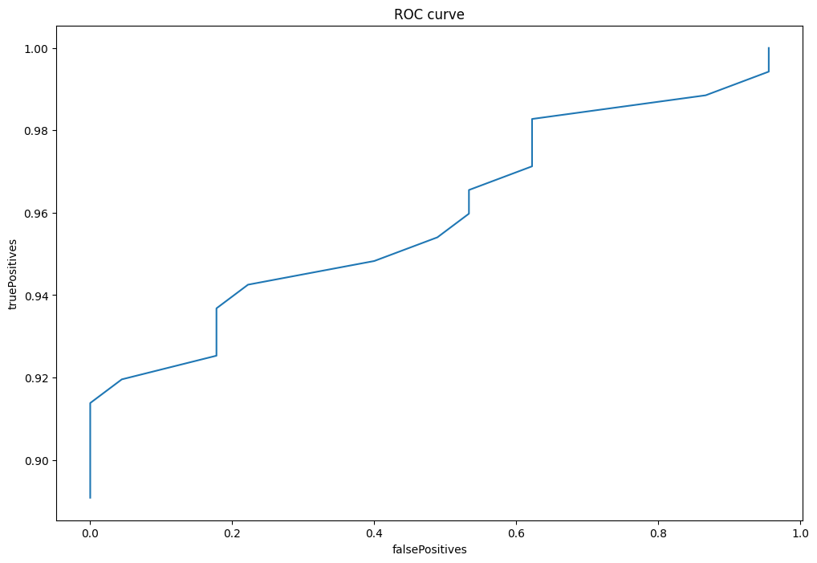

```python
plt.figure()
plt.plot(false_positives, true_positives)
plt.xlabel('falsePositives')
plt.ylabel('truePositives')
plt.title('ROC curve')
plt.show()
```

Generated on 2025-08-23 22:58:00 from `direct_use_nonparametric.ipynb`

Part of the SHMTools Python Package - Structural Health Monitoring Toolkit